### Major libraries that have been used in this tutorial

```python
import math
import numpy as np
import matplotlib.pyplot as plt
import scipy
import sympy
```

# Introduction to Mathematical Computations with Python

Welcome to Numerical Computations!

In this simple tutorial, we will learn about python3's basic commands and methods that we will use them regularly for numerical computations. Consider that we use Python 3.7

# Note

This tutorial has been created by $\href{https://hnxj.github.io/}{Hamed \: Nejat}$ for Numerical computations course of $\href{https://ee.sharif.edu}{Electrical \: Engineering \: Department \: of \: Sharif \: University \: of \: Technology}$, with major help of official documents of Numpy, Scipy, Matplotlib and Sympy. special thanks to all other python developers, this tutorial is free to use.

# Anaconda with Python3.7 Download links:

Windows (x64/x86) (~490MB) : https://repo.anaconda.com/archive/Anaconda3-2019.07-Windows-x86_64.exe

for MacOS (~650MB) : https://repo.anaconda.com/archive/Anaconda3-2019.07-MacOSX-x86_64.pkg

for Linux (~510MB) : https://repo.anaconda.com/archive/Anaconda3-2019.07-Linux-x86_64.sh

Make sure that JupyterLab is installed by this command on Anaconda Prompt :

-->conda install jupyter

## Virtual environments:

In anaconda prompt, write:

-->conda create -n env_name python=3.7

Then everytime you want to code for this course, write:

-->conda activate evn_name

And when you dont want to use this env:

-->conda deactivate env_name

for anaconda users:

-->conda install jupyter

for main python users:

-->pip install

## Run Jupyter notebook:

Open Anaconda prompt, one of the ways is to search "Anaconda prompt" in windows search.

After opening of Anaconda Prompt, Enter:

-->jupyter lab

Then, you are in jupyter environment. click on file tab, then click on new notebook.

## Run Spyder scientific IDE

On cmd/terminal, install spyder using this commands:

-->conda install spyder

To run:

-->spyder

#### Contact

For more questions about tutorial class or homeworks:

contact us : hamednejat7@gmail.com

## Key commands and methods

### 0: Basic commands

```
EXAMPLES:

In the begining of almost every programming language, we try to print a text or a number. python is easy to
start! here are some examples of printing variables:
```

### Input/Output (I/O)

```python
print("You will never walk alone") # Raw string
print("There is" + " a " + "GoldenSky :)" # Multi strings
    " Walk on", "trough the rain") # multi line
```

```
You will never walk alone
There is a GoldenSky :) Walk on trough the rain
```

```python
a = int(input("Enter int number"))
b = float(input("enter float"))
s = str(input("Enter string"))

print(a, b, s)
```

```
12653451253 123.123 YNWA
```

```python
print(6) # Integers
print(-7) # Integers
print(18.0) # Floats
print("18.0 " + str(-32.4353)) # Numbers to string
print(float("18.34") + 32.4353) # Strings to number
print(float("-18.34") + 32.4353) # Signed strings to number, Sign is included in number while it was converted from string to number!
```

```
6
-7
18.0
18.0 -32.4353
50.7753
14.095299999999998
```

```python
print("First number: {}, Second number: {} and so on ...".format(4.01, 3.98))

print ('%.2f'%(11.1725612)) # 2-digit precision, rounded down because 11.1725612 < 11.175
print ('%.2f'%(11.1775612)) # 2-digit presicion rounded up because 11.1775612 > 11.175

print('%.5f'%(float("18.34") + 32.4353)) # Strings to number, 5-digit precision
print('%.3f'%(float("-18.34") + 32.4353)) # Signed strings to number, 3-digit precision

print('%f %d %s'%(11.13, 11.13, 11.13)) # printing float, integer and string in same command.
print('%f'%(1323.12312312312)) # NOTE!: default float precision is 6-digits
```

```
First number: 4.01, Second number: 3.98 and so on ...
11.17
11.18
50.77530
14.095
11.130000 11 11.13
1323.123123
```

### 1: Some data type and variable assignment

#### 1.1: integer, float, string, char

```python
a = 4 # integer
b = -5.12 # float
c = "Estereeng" # string

# char is almost same with str in python, except char array in classes
d = chr(113) # <C: char> = chr(<I: integer>) method returns the character that has ascii=I
e = ord('q') # <I: integer> = ord(<C: char>) method returns the ascii that char=C

print("\nType of a is :", type(a), "a :", a,
      "\nType of b is :", type(b), "b :", b,
      "\nType of c is :", type(c), "c :", c,
      "\nType of d is :", type(d), "d :", d,
      "\nType of e is :", type(e), "d :", e)
```

```
Type of a is : <class 'int'> a : 4
Type of b is : <class 'float'> b : -5.12
Type of c is : <class 'str'> c : Estereeng
Type of d is : <class 'str'> d : q
Type of e is : <class 'int'> d : 113
```

#### 1.2: Dictionary

```python
e = dict() # dict :: e[<Key>] = <Val>
e["asd"] = 12 # assigning num to string key
e[1] = a # integer to integer
e[b] = 'L' # char (string) to float

print("\nType of e is :", type(e), "\n e :", e)
print("e[\"asd\"] is : ", e["asd"])
```

```
Type of e is : <class 'dict'>
 e : {'asd': 12, 1: 4, -5.12: 'L'}
e["asd"] is :  12
```

#### 0.1.3: List

```python
f = list() # alternate for list / f = [1, 1.1, list]
f.append(1) # appending an integer
f.append(1.1) # appending a float

f.append("paganini") # appending a string
f.append(e) # appending a dictionary!
print("\nType of e is :", type(f), "e :", f)

f.pop(2) # pop 2nd element
print("\nType of e is :", type(f), "e :", f)
f.pop() # pop last element
print("\nType of e is :", type(f), "e :", f)
```

```
Type of e is : <class 'list'> e : [1, 1.1, 'paganini', {'asd': 12, 1: 4, -5.12: 'L'}]

Type of e is : <class 'list'> e : [1, 1.1, {'asd': 12, 1: 4, -5.12: 'L'}]

Type of e is : <class 'list'> e : [1, 1.1]
```

#### 1.3: Set

```python
f = set() # alternate for list / f = [1, 1.1, list]
f.add(1) # add an integer to the set
f.add(1.1) # appending a float
f.add(2)
f.add(-1)

f.add("vivaldi") # appending a string
f.add("antonio")
# f.add(e) # appending a dictionary!
print("\nType of e is :", type(f), "e :", f)

f.remove("antonio") # remove one existing element

try: # prevents unexcepted errors and interrupts in program
    f.remove("bach") # key is not in the set
except KeyError:
    print("\nKey is not in the set")
except:
    print("Unknown error")

print("\nType of e is :", type(f), "e :", f)
f.pop() # pop last element
print("\nType of e is :", type(f), "e :", f)
```

```
Type of e is : <class 'set'> e : {'vivaldi', 1, 2, 1.1, 'antonio', -1}

Key is not in the set

Type of e is : <class 'set'> e : {'vivaldi', 1, 2, 1.1, -1}

Type of e is : <class 'set'> e : {1, 2, 1.1, -1}
```

#### 1.4: Computation

In this subsection, we will do some maths computations and evaluate errors.

```python
import math
import numpy as np
import pandas as pd
import matplotlib.pyplot as plt
from scipy.optimize import fsolve


a = 12.250
b = 27.601
c = a * b
d = a / b

print(a, b, c, d)
```

```
12.25 27.601 338.11225 0.443824499112351
```

```python
a = 3.131
b = 13.313
c = a ** b # a power b
d = np.sqrt(b) # radical b

print(a, b, c, d)
```

```
3.131 13.313 3972177.79380536 3.6486983980592314
```

```python
a = 3.131
b = np.sin(a) # numpy sinus; is radian based
c = np.cos(a) # numpy cosinus; is radian based
d = np.exp(c) # exponential

print(a, b, c, d)
```

```
3.131 0.010592455500673467 -0.9999438983695367 0.3679000803868474
```

```python
a = -3.131 + 4.023j # complex number
b = np.sin(a) # numpy sinus; is radian based
c = np.cos(a) # numpy cosinus; is radian based
d = np.exp(c) # exponential

print(a, b, c, d)
```

```
(-3.131+4.023j) (-0.29598688665547973-27.92371377790813j) (-27.941611960486863+0.2957972903163078j) (7.011789697864798e-13+2.1367541336939334e-13j)
```

## Some Random Numbers

```python
a = np.random.rand(5) # 10 random numbers uniformly between 0-1
b = np.random.randn(1000) # 1000 Gaussian standard distributed random numbers with mean = 0, std = 1
c = np.random.randint(-3, 14, 10) # 10 random integers between -3 and 13
d = np.random.gamma(2.5, 1, [2, 2]) # beta, gumbel, ... other distributions are available

print(a)
print(np.mean(b))
print(np.var(b))
print(c)
print(d)
```

```
[0.72043503 0.42271848 0.34518329 0.52325653 0.95223927]
0.0489575868952785
0.9714511651099623
[13  5  2  5  7  8  9 -1 -1  9]
[[0.52462323 1.44135035]
 [3.56640445 7.56055784]]
```

## 1.5 Stats

```python
import numpy as np

interval_first = 0
interval_last = 10
step = 2
amount = 33

e = np.arange(interval_first, interval_last, step) # equivalent to matlab's i:j with step
f = np.linspace(interval_first, interval_last, amount) # Splits line space between 1 and 10 into 25 numbers
g = np.mean(e)
h = np.var(f)

i = np.std(f)
j = np.max(e)
k = np.min(f)
l = np.median(e)

print(e)
print(f)
print(len(e)) # returns length of structure
print(len(f)) # returns length of structure

print(g, h, i)
print(j, k, l)
```

```
[0 2 4 6 8]
[ 0.      0.3125  0.625   0.9375  1.25    1.5625  1.875   2.1875  2.5
  2.8125  3.125   3.4375  3.75    4.0625  4.375   4.6875  5.      5.3125
  5.625   5.9375  6.25    6.5625  6.875   7.1875  7.5     7.8125  8.125
  8.4375  8.75    9.0625  9.375   9.6875 10.    ]
5
33
4.0 8.854166666666666 2.9755951785595207
8 0.0 4.0
```

## 2: Loop and Condition

```python
import numpy as np
first = -4
last = 6
step = 2
cnt = 0.5

np_array1 = np.array([1, 0.7, -4, 2.0 + 2.0j, -0.5j])
np_array2 = np.array([[1, 2], [0.5j, -2], [4.0, 0.3j]])
```

#### For loops

```python
for i in range(first, last, step): # ranged loop
    print(i**2.5)

for j in np_array1: # structured loop
    print(j)

for i, j in np_array2: # structured double loop
    print(i, j)
```

[output not shown]

```python
for i in range(10):
    print(i)
```

```
0
1
2
3
4
5
6
7
8
9
```

#### While loops

```python
while cnt < 10:
    cnt *= 2
    print(cnt)
```

```
1.0
2.0
4.0
8.0
16.0
```

#### If conditions

```python
if step > 10:
    pass # the command that does nothing!
    # the code
elif step == 10: # Else If equivalent
    pass
    # the code
elif step == 9:
    quit() # Exit from the code or program !
else: # otherwise
    print("Nothing else matters")
```

```
Nothing else matters
```

## 3: Functions

```python
import numpy as np

# Basic recursive function
def gcd(a, b): # Greatest Common Divisor (GCD)
    if b > a:
        (a, b) (b, a) # nice swap in Python!
    if b == 0:
        return a
    return gcd(b, a%b)


R = 14
a = -1
f = lambda tau : 14 - ((1.0 - np.exp(-tau))/(1.0 - np.exp(-a*tau)))


print(gcd(2436, 504))
print(f(12))

# IMPORTANT NOTE: Python has recursion limit, default recursion limit is 1000.
# you can change it by setrecursionlimit(<New Limit>)
import sys
sys.setrecursionlimit(10000)
```

```
84
14.000006144212353
```

```python
# Void function
def say_hello():
    print("Hello World :)")
    return # void return


say_hello()
```

```
Hello World :)
```

```python
# lambda function
hemographic1 = lambda x : (2 * x + 4) / (3 * x - 1)
print(hemographic1(4))
```

```
1.0909090909090908
```

## 4: Classes

Calm down, Its just a class! The other parts like plots will be discussed in the next tutorial

```python
from matplotlib import pyplot as plt
import numpy

class painter:

    def __init__(self, boom_width, boom_height):
        self.boom_width = boom_width
        self.boom_height = boom_height
        self.fig, self.ax = plt.subplots()

    def sinusy(self, x):
        self.ax.plot(x, np.sin(x))
        return

    def expony(self, x):
        self.ax.plot(x, np.exp(x))
        return

    def free_draw(self, x, y):
        self.ax.plot(x, y)
        print("Mahmud, 10 saale az Salafchegan")
        return
```

```
Mahmud, 10 saale az Salafchegan
```

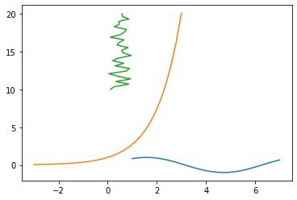

```python
msr = painter(100, 100)
msr.sinusy(np.linspace(1, 7, 30))
msr.expony(np.linspace(-3, 3, 30))
msr.free_draw(np.random.rand(30), np.linspace(10, 20, 30))
```

# 5.Plotting with matplotlib

# Plotting

## Here we will learn about simple plotting tools.

plotting in matlab has many materials, read matplotlib docs for more info

Initialize arrays:

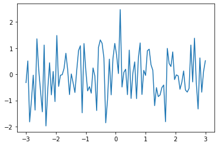

```python
from matplotlib import pyplot as plt

x = np.linspace(-3, 3, 100)
y1 = np.exp(x)
y2 = np.cos(x)
y3 = np.random.randn(100)


plt.plot(x, y3)
plt.show()
# print(dir(plt))
```

Initialize figures

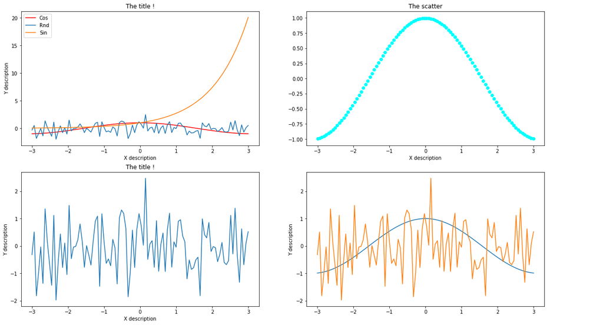

```python
fig, ax = plt.subplots(nrows=2, ncols=2) # number of subplots
fig.set_figwidth(19) # figure width in cm
fig.set_figheight(11) # figure height in cm


ax[0, 0].plot(x, y2, label='Cos', color='red') # plotting with specs
ax[0, 0].plot(x, y3, label='Rnd') # colors, scatters and ...
ax[0, 0].plot(x, y1, label='Sin')
ax[0, 1].scatter(x, y2, label='Cos', color='cyan')
ax[1, 0].plot(x, y3, label='Rnd')
ax[1, 1].plot(x, y2, label='Cos')
ax[1, 1].plot(x, y3, label='Rnd')


ax[0, 1].annotate('Sin', (5, 0.5),
            xytext=(0.8, 0.9), textcoords='axes fraction',
            arrowprops=dict(facecolor='black', shrink=0.05),
            fontsize=16,
            horizontalalignment='right', verticalalignment='top') # annotation cursor


ax[0, 0].set_title("The title !")
ax[0, 0].set_xlabel("X description")
ax[0, 0].set_ylabel("Y description")

ax[1, 0].set_title("The title !")
ax[1, 0].set_xlabel("X description")
ax[1, 0].set_ylabel("Y description")

ax[0, 1].set_title("The scatter")
ax[0, 1].set_xlabel("X description")
ax[1, 1].set_ylabel("Y description")

ax[0, 0].legend()
fig.show()
```

# 6. Using Scipy

## here we have an example of scipy solving equation. we will use it in the homeworks

```
The solution is tau = 1.021651
at which the value of the expression is -0.000000
```

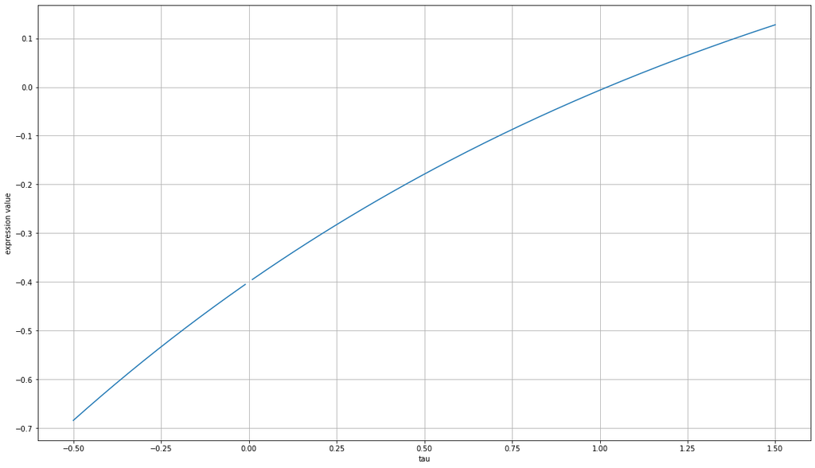

```python
import numpy as np
import matplotlib.pyplot as plt
from scipy.optimize import fsolve

a = 0.5
R = 1.6

func = lambda tau : R - ((1.0 - np.exp(-tau))/(1.0 - np.exp(-a*tau)))

# Plot it

tau = np.linspace(-0.5, 1.5, 200)
fig, ax = plt.subplots(1, 1)
fig.set_figwidth(19)
fig.set_figheight(11)

ax.plot(tau, func(tau))
ax.set_xlabel("tau")
ax.set_ylabel("expression value")
ax.grid(True)
fig.show()

# Use the numerical solver to find the roots

tau_initial_guess = 0.5
tau_solution = fsolve(func, tau_initial_guess)

print("The solution is tau = %f"%(tau_solution))
print("at which the value of the expression is %f"%(func(tau_solution)))
```

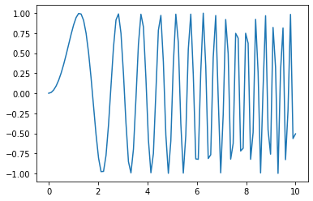

```python
from matplotlib.pyplot import *
import numpy as np

x = np.linspace(0, 10, 100)
y = np.sin(x**2)

plot(x, y)
show()
```